# Proposal

Zhang fengyu

April 4 2020

## Data Description

The data is about a study of a dental disease.

```r
library(dplyr)
library(ggplot2)
library(gridExtra)
teeth <- read.csv("teethdata/Teeth_ILDoData.csv")
str(teeth)
```

```
## 'data.frame':    65890 obs. of  20 variables:
##  $ id                        : int  1 1 1 1 1 1 1 1 1 1 ...
##  $ tooth                     : int  2 3 5 12 13 14 15 18 19 29 ...
##  $ event..1...fail..0...cens.: int  0 0 0 0 0 0 0 0 0 0 ...
##  $ time..years.              : num  1.2 1.2 1.2 1.2 1.2 1.2 1.2 1.2 1.2 1.2 ...
##  $ Mobility                  : num  0 0 0 0 0 0 0 0 0 0 ...
##  $ BOP.                      : num  0 16.7 0 0 33.3 ...
##  $ Plaque.                   : num  16.7 16.7 0 16.7 16.7 ...
##  $ Pdmean                    : num  2.17 2 1.83 1.83 2 ...
##  $ CALmean                   : num  2.17 2 1.83 1.83 2 ...
##  $ Crown                     : Factor w/ 2 levels "Crown","No Crown": 2 2 2 2 2 2 2 2 2 2 ...
##  $ Implant                   : Factor w/ 2 levels "Implant","No Implant": 2 2 2 2 2 2 2 2 2 2 ...
##  $ Missing.                  : Factor w/ 2 levels "Missing","Not Missing": 2 2 2 2 2 2 2 2 2 2 ...
##  $ Filled.                   : Factor w/ 2 levels "Filled","Not Filled": 1 2 2 1 2 1 2 2 1 2 ...
##  $ Decayed.                  : Factor w/ 2 levels "Decayed","Not Decayed": 1 1 1 2 1 2 1 1 2 1 ...
##  $ D.F.sites                 : int  1 1 1 1 1 1 1 1 1 1 ...
##  $ Age                       : int  33 33 33 33 33 33 33 33 33 33 ...
##  $ Gender                    : Factor w/ 2 levels "Female","Male": 2 2 2 2 2 2 2 2 2 2 ...
##  $ Diabetes..Y.N.            : Factor w/ 2 levels "Diabetes","No Diabetes": 2 2 2 2 2 2 2 2 2 2 ...
##  $ Tobacco.Use               : Factor w/ 2 levels "Had Tobacco",..: 2 2 2 2 2 2 2 2 2 2 ...
##  $ Molar.Tooth.              : logi  TRUE TRUE FALSE FALSE FALSE TRUE ...
```

In order to be operable, we select the observations with “tooth=2” which is a molar and rename some of the columns for convenience. Also, we remove some irrelevant variables.

```r
teeth2 <- filter(teeth, tooth==2) ## select data with tooth=2
teeth2 = rename(teeth2,  censor = event..1...fail..0...cens., ## rename
                Time = time..years., Plaque=Plaque., Diabetes = Diabetes..Y.N.,
                Tobacco = Tobacco.Use) ## rename
teeth2 = select(teeth2, -c(id, tooth, Mobility,Missing., Implant, Molar.Tooth.))
head(teeth2)
```

```
##   censor      Time BOP.   Plaque   Pdmean  CALmean    Crown Filled.    Decayed.
## 1      0 1.2000000    0 16.66667 2.166667 2.166667 No Crown  Filled     Decayed
## 2      0 0.3726027    0  0.00000 2.333333 2.333333    Crown  Filled Not Decayed
## 3      0 4.8136986    0 50.00000 2.333333 2.333333 No Crown  Filled Not Decayed
## 4      0 1.1287671   50  0.00000 3.666667 3.666667 No Crown  Filled Not Decayed
## 5      0 4.7369863    0 33.33333 2.333333 2.333333    Crown  Filled Not Decayed
## 6      0 0.1917808    0  0.00000 3.166667 4.666667 No Crown  Filled Not Decayed
##   D.F.sites Age Gender    Diabetes           Tobacco
## 1         1  33   Male No Diabetes Never Had Tobacco
## 2         5  56   Male No Diabetes Never Had Tobacco
## 3         1  64 Female No Diabetes Never Had Tobacco
## 4         5  64   Male No Diabetes       Had Tobacco
## 5         5  67   Male No Diabetes Never Had Tobacco
## 6         1  57   Male No Diabetes       Had Tobacco
```

Goal: Explore whether the covariates can affect the survival time significantly?

## EDA

First look at the censor rate.

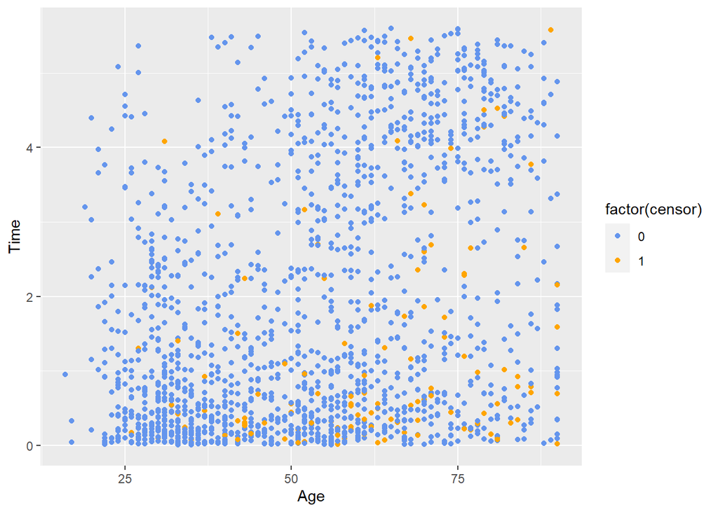

```r
a <- ggplot(data=teeth2, aes(x=Age,y=Time))
a + geom_point(aes(color = factor(censor)), size=1.5) +
  scale_color_manual(values=c("#6495ED","#FFA500"))
```

Each point in the figure above represents an observation labeled with different colors to indicate if it is censored (0 for censoring and 1 for failure). From the figure, we can see that the censor rate is high. Therefore, we consider a cure rate model to fit the data.

Moreover, we roughly explore the relationship among the variables.

```r
qq <- quantile(teeth2$Age, seq(0,1,0.2), na.rm = T)
Age.seg <- mutate(teeth2, Age.quint = cut(Age, qq)) %>%
  group_by(Age.quint)
Age.seg <- na.omit(Age.seg)
head(Age.seg)
```

```
## # A tibble: 6 x 15
## # Groups:   Age.quint [3]
##   censor  Time  BOP. Plaque Pdmean CALmean Crown Filled. Decayed. D.F.sites
##    <int> <dbl> <dbl>  <dbl>  <dbl>   <dbl> <fct> <fct>   <fct>        <int>
## 1      0 1.2       0   16.7   2.17    2.17 No C~ Filled  Decayed          1
## 2      0 0.373     0    0     2.33    2.33 Crown Filled  Not Dec~         5
## 3      0 4.81      0   50     2.33    2.33 No C~ Filled  Not Dec~         1
## 4      0 1.13     50    0     3.67    3.67 No C~ Filled  Not Dec~         5
## 5      0 4.74      0   33.3   2.33    2.33 Crown Filled  Not Dec~         5
## 6      0 0.192     0    0     3.17    4.67 No C~ Filled  Not Dec~         1
## # ... with 5 more variables: Age <int>, Gender <fct>, Diabetes <fct>,
## #   Tobacco <fct>, Age.quint <fct>
```

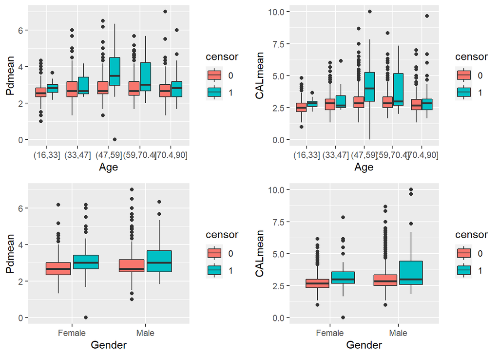

```r
p = ggplot(Age.seg, aes(x = Age.quint, fill = factor(censor)))
p1 = p + geom_boxplot(aes(y = Pdmean)) + scale_fill_discrete(name="censor") + xlab("Age")
p2 = p + geom_boxplot(aes(y = CALmean)) + scale_fill_discrete(name="censor") + xlab("Age")

q = ggplot(Age.seg, aes(x = factor(Gender), fill = factor(censor)))
p3 = q + geom_boxplot(aes(y = Pdmean)) + scale_fill_discrete(name="censor") + xlab("Gender")
p4 = q + geom_boxplot(aes(y = CALmean)) + scale_fill_discrete(name="censor") + xlab("Gender")
grid.arrange(p1,p2,p3,p4,nrow = 2)
```

## Model

In survival analysis, one usually assumes that all subjects under study will eventually experience the event of interest. However, there are various situations for which this assumption is not realistic. For instance, when the event of interest is the time until a patient progresses or relapses from a certain disease, then patients who are cured from the disease will never experience the event. Those observations will be considered as “long-term survivors” or as “cured,” and their survival time will be set to infinity. Cure models are survival models that have been developed to take this feature into account.

When information on covariates is present, a commonly used cure regression model is the mixture cure model. It assumes that the survival function $S(t|x,z) = P(T>t|X=x,Z=z)$ of survival time $T$ given a set of covariates $(X^t,Z^t)$ is given by :
$$S(t|x,z) = 1-p(x)+p(x)S_u(t|z),\qquad t\geqslant 0,$$
where $p(x)=P(B=1|X=x)$ is the conditional probability of being uncured (often referred to as the ‘incidence’) with $B=I(T<\infty)$ the latent uncured status; and $S_u(t|z)=P(T>t|B=1,Z=z)$ is the conditional survival function for the uncured subjects (often referred to as the ‘latency’). Amico et al.(2018) proposed a single-index model for $p(x)$ to allow the cure rate to be more flexible, i.e., there exists an unknown link function $g(\cdot)$ such that :
$$p(x)=g(\gamma^\mathrm{T}x).$$
The link function can be any (smooth) function with values between 0 and 1, and will be estimated nonparametrically using kernel methods.

For the part of latency, we consider a Cox propotional hazards (PH) model (Cox 1972) with the following form :
$$S_u(t|z) = S_0(t)^{\exp(\beta^T z)},$$
where $S_0(t)=P(T>t|B=1)$ is the baseline conditional survival function. The conditional hazard function is given by $\lambda_u(t|z) = \lambda_0(t)\exp(\beta^T z),$ where $\lambda_0(t)$ is the baseline conditional hazard function.

In the survival analysis, we usually observe the couple $(Y,\delta)$ instead of the survival time $T$, where $Y = \min(T,C),\delta = I(T\leqslant C)$. Let $(Y_i,\delta_i,X_i,Z_i),i=1\ldots,n$ be i.i.d. observations. Assuming non-informative censoring, the likelihood of an observation $(y,\delta,x,z)$ is given by :
$$L(y,\delta,x,z) = \{g(\gamma^Tx)f_u(y|z)\}^\delta\{1-g(\gamma^Tx)S_u(y|z)\}^{1-\delta},$$
where $f_u(t|z) = -\frac{d}{dt}S_u(t|z).$

## To do

Amico et al.(2018) proposed a estimation method using EM algorithm where the link function $g(\cdot)$ is estimated by kernel method. We will apply this method to the data and evaluate the performance.